# Loan Data Visualization Project-Exploratory

## Problem Statement

#### Finding the key factors driving Prosper Score and Borrower's APR

```python
## Importing essential packages and libraries

import numpy as np
import pandas as pd
import matplotlib.pyplot as plt
%matplotlib inline
import seaborn as sns
```

```python
# Code to ignore warnings generated by python

import warnings
warnings.filterwarnings('ignore')
```

```python
# Setting maximum number of rows and columns for display purpose

pd.set_option('display.max_rows',100)
pd.set_option('display.max.columns',100)
```

```python
# Reading the data and placing it in loan_original df

loan_original = pd.read_csv("prosperLoanData.csv")
loan_original.head()
```

|  | ListingKey | ListingNumber | ListingCreationDate | CreditGrade | Term | LoanStatus | ClosedDate | BorrowerAPR | BorrowerRate | LenderYield | EstimatedEffectiveYield | EstimatedLoss | EstimatedReturn | ProsperRating (numeric) | ProsperRating (Alpha) | ProsperScore | ListingCategory (numeric) | BorrowerState | Occupation | EmploymentStatus | EmploymentStatusDuration | IsBorrowerHomeowner | CurrentlyInGroup | GroupKey | DateCreditPulled | CreditScoreRangeLower | CreditScoreRangeUpper | FirstRecordedCreditLine | CurrentCreditLines | … |
| --- | --- | --- | --- | --- | --- | --- | --- | --- | --- | --- | --- | --- | --- | --- | --- | --- | --- | --- | --- | --- | --- | --- | --- | --- | --- | --- | --- | --- | --- | --- |
| 0 | 1021339766868145413AB3B | 193129 | 2007-08-26 19:09:29.263000000 | C | 36 | Completed | 2009-08-14 00:00:00 | 0.16516 | 0.1580 | 0.1380 | NaN | NaN | NaN | NaN | NaN | NaN | 0 | CO | Other | Self-employed | 2.0 | True | True | NaN | 2007-08-26 18:41:46.780000000 | 640.0 | 659.0 | 2001-10-11 00:00:00 | 5.0 | … |
| 1 | 10273602499503308B223C1 | 1209647 | 2014-02-27 08:28:07.900000000 | NaN | 36 | Current | NaN | 0.12016 | 0.0920 | 0.0820 | 0.07960 | 0.0249 | 0.05470 | 6.0 | A | 7.0 | 2 | CO | Professional | Employed | 44.0 | False | False | NaN | 2014-02-27 08:28:14 | 680.0 | 699.0 | 1996-03-18 00:00:00 | 14.0 | … |
| 2 | 0EE9337825851032864889A | 81716 | 2007-01-05 15:00:47.090000000 | HR | 36 | Completed | 2009-12-17 00:00:00 | 0.28269 | 0.2750 | 0.2400 | NaN | NaN | NaN | NaN | NaN | NaN | 0 | GA | Other | Not available | NaN | False | True | 783C3371218786870A73D20 | 2007-01-02 14:09:10.060000000 | 480.0 | 499.0 | 2002-07-27 00:00:00 | NaN | … |
| 3 | 0EF5356002482715299901A | 658116 | 2012-10-22 11:02:35.010000000 | NaN | 36 | Current | NaN | 0.12528 | 0.0974 | 0.0874 | 0.08490 | 0.0249 | 0.06000 | 6.0 | A | 9.0 | 16 | GA | Skilled Labor | Employed | 113.0 | True | False | NaN | 2012-10-22 11:02:32 | 800.0 | 819.0 | 1983-02-28 00:00:00 | 5.0 | … |
| 4 | 0F023589499656230C5E3E2 | 909464 | 2013-09-14 18:38:39.097000000 | NaN | 36 | Current | NaN | 0.24614 | 0.2085 | 0.1985 | 0.18316 | 0.0925 | 0.09066 | 3.0 | D | 4.0 | 2 | MN | Executive | Employed | 44.0 | True | False | NaN | 2013-09-14 18:38:44 | 680.0 | 699.0 | 2004-02-20 00:00:00 | 19.0 | … |

### Assessing the dataset

```python
# Dataset consists of 113937 rows, 81 columns.
# Info shows that various columns have high missing values

print(loan_original.info())
loan_original.shape
```

```
<class 'pandas.core.frame.DataFrame'>
RangeIndex: 113937 entries, 0 to 113936
Data columns (total 81 columns):
ListingKey                             113937 non-null object
ListingNumber                          113937 non-null int64
ListingCreationDate                    113937 non-null object
CreditGrade                            28953 non-null object
Term                                   113937 non-null int64
LoanStatus                             113937 non-null object
ClosedDate                             55089 non-null object
BorrowerAPR                            113912 non-null float64
BorrowerRate                           113937 non-null float64
LenderYield                            113937 non-null float64
EstimatedEffectiveYield                84853 non-null float64
EstimatedLoss                          84853 non-null float64
EstimatedReturn                        84853 non-null float64
ProsperRating (numeric)                84853 non-null float64
ProsperRating (Alpha)                  84853 non-null object
ProsperScore                           84853 non-null float64
ListingCategory (numeric)              113937 non-null int64
BorrowerState                          108422 non-null object
Occupation                             110349 non-null object
EmploymentStatus                       111682 non-null object
EmploymentStatusDuration               106312 non-null float64
IsBorrowerHomeowner                    113937 non-null bool
CurrentlyInGroup                       113937 non-null bool
GroupKey                               13341 non-null object
DateCreditPulled                       113937 non-null object
CreditScoreRangeLower                  113346 non-null float64
CreditScoreRangeUpper                  113346 non-null float64
FirstRecordedCreditLine                113240 non-null object
CurrentCreditLines                     106333 non-null float64
OpenCreditLines                        106333 non-null float64
TotalCreditLinespast7years             113240 non-null float64
OpenRevolvingAccounts                  113937 non-null int64
OpenRevolvingMonthlyPayment            113937 non-null float64
InquiriesLast6Months                   113240 non-null float64
TotalInquiries                         112778 non-null float64
CurrentDelinquencies                   113240 non-null float64
AmountDelinquent                       106315 non-null float64
```

[output cut: 32 more lines]

```
LP_CustomerPrincipalPayments           113937 non-null float64
LP_InterestandFees                     113937 non-null float64
LP_ServiceFees                         113937 non-null float64
LP_CollectionFees                      113937 non-null float64
LP_GrossPrincipalLoss                  113937 non-null float64
LP_NetPrincipalLoss                    113937 non-null float64
LP_NonPrincipalRecoverypayments        113937 non-null float64
PercentFunded                          113937 non-null float64
Recommendations                        113937 non-null int64
InvestmentFromFriendsCount             113937 non-null int64
InvestmentFromFriendsAmount            113937 non-null float64
Investors                              113937 non-null int64
dtypes: bool(3), float64(50), int64(11), object(17)
memory usage: 68.1+ MB
None
```

```
(113937, 81)
```

```python
# Understanding statistical spread of the data

loan_original.describe()
```

|  | ListingNumber | Term | BorrowerAPR | BorrowerRate | LenderYield | EstimatedEffectiveYield | EstimatedLoss | EstimatedReturn | ProsperRating (numeric) | ProsperScore | ListingCategory (numeric) | EmploymentStatusDuration | CreditScoreRangeLower | CreditScoreRangeUpper | CurrentCreditLines | OpenCreditLines | TotalCreditLinespast7years | OpenRevolvingAccounts | OpenRevolvingMonthlyPayment | InquiriesLast6Months | TotalInquiries | CurrentDelinquencies | AmountDelinquent | DelinquenciesLast7Years | PublicRecordsLast10Years | PublicRecordsLast12Months | RevolvingCreditBalance | BankcardUtilization | AvailableBankcardCredit | … |
| --- | --- | --- | --- | --- | --- | --- | --- | --- | --- | --- | --- | --- | --- | --- | --- | --- | --- | --- | --- | --- | --- | --- | --- | --- | --- | --- | --- | --- | --- | --- |
| count | 1.139370e+05 | 113937.000000 | 113912.000000 | 113937.000000 | 113937.000000 | 84853.000000 | 84853.000000 | 84853.000000 | 84853.000000 | 84853.000000 | 113937.000000 | 106312.000000 | 113346.000000 | 113346.000000 | 106333.000000 | 106333.000000 | 113240.000000 | 113937.00000 | 113937.000000 | 113240.000000 | 112778.000000 | 113240.000000 | 106315.000000 | 112947.000000 | 113240.000000 | 106333.000000 | 1.063330e+05 | 106333.000000 | 106393.000000 | … |
| mean | 6.278857e+05 | 40.830248 | 0.218828 | 0.192764 | 0.182701 | 0.168661 | 0.080306 | 0.096068 | 4.072243 | 5.950067 | 2.774209 | 96.071582 | 685.567731 | 704.567731 | 10.317192 | 9.260164 | 26.754539 | 6.96979 | 398.292161 | 1.435085 | 5.584405 | 0.592052 | 984.507059 | 4.154984 | 0.312646 | 0.015094 | 1.759871e+04 | 0.561309 | 11210.225447 | … |
| std | 3.280762e+05 | 10.436212 | 0.080364 | 0.074818 | 0.074516 | 0.068467 | 0.046764 | 0.030403 | 1.673227 | 2.376501 | 3.996797 | 94.480605 | 66.458275 | 66.458275 | 5.457866 | 5.022644 | 13.637871 | 4.63097 | 447.159711 | 2.437507 | 6.429946 | 1.978707 | 7158.270157 | 10.160216 | 0.727868 | 0.154092 | 3.293640e+04 | 0.317918 | 19818.361309 | … |
| min | 4.000000e+00 | 12.000000 | 0.006530 | 0.000000 | -0.010000 | -0.182700 | 0.004900 | -0.182700 | 1.000000 | 1.000000 | 0.000000 | 0.000000 | 0.000000 | 19.000000 | 0.000000 | 0.000000 | 2.000000 | 0.00000 | 0.000000 | 0.000000 | 0.000000 | 0.000000 | 0.000000 | 0.000000 | 0.000000 | 0.000000 | 0.000000e+00 | 0.000000 | 0.000000 | … |
| 25% | 4.009190e+05 | 36.000000 | 0.156290 | 0.134000 | 0.124200 | 0.115670 | 0.042400 | 0.074080 | 3.000000 | 4.000000 | 1.000000 | 26.000000 | 660.000000 | 679.000000 | 7.000000 | 6.000000 | 17.000000 | 4.00000 | 114.000000 | 0.000000 | 2.000000 | 0.000000 | 0.000000 | 0.000000 | 0.000000 | 0.000000 | 3.121000e+03 | 0.310000 | 880.000000 | … |
| 50% | 6.005540e+05 | 36.000000 | 0.209760 | 0.184000 | 0.173000 | 0.161500 | 0.072400 | 0.091700 | 4.000000 | 6.000000 | 1.000000 | 67.000000 | 680.000000 | 699.000000 | 10.000000 | 9.000000 | 25.000000 | 6.00000 | 271.000000 | 1.000000 | 4.000000 | 0.000000 | 0.000000 | 0.000000 | 0.000000 | 0.000000 | 8.549000e+03 | 0.600000 | 4100.000000 | … |
| 75% | 8.926340e+05 | 36.000000 | 0.283810 | 0.250000 | 0.240000 | 0.224300 | 0.112000 | 0.116600 | 5.000000 | 8.000000 | 3.000000 | 137.000000 | 720.000000 | 739.000000 | 13.000000 | 12.000000 | 35.000000 | 9.00000 | 525.000000 | 2.000000 | 7.000000 | 0.000000 | 0.000000 | 3.000000 | 0.000000 | 0.000000 | 1.952100e+04 | 0.840000 | 13180.000000 | … |
| max | 1.255725e+06 | 60.000000 | 0.512290 | 0.497500 | 0.492500 | 0.319900 | 0.366000 | 0.283700 | 7.000000 | 11.000000 | 20.000000 | 755.000000 | 880.000000 | 899.000000 | 59.000000 | 54.000000 | 136.000000 | 51.00000 | 14985.000000 | 105.000000 | 379.000000 | 83.000000 | 463881.000000 | 99.000000 | 38.000000 | 20.000000 | 1.435667e+06 | 5.950000 | 646285.000000 | … |

### Observations made:

1. There are 113937 rows in loan_original dataset, it can be noticed that missing values are present in few columns and needs to be treated.
2. ListingCreationDate Attribute is in Object Format, should have been in datetime format
3. Also statistical summary shows that maximum term chosen by the customers is 60 months, this infers that maximum term allowed by the bank is 60 months.
4. ProsperScore has the maximum of 11, which is incorrect as the score is measured from 1 to 10. This need some cleaning.
5. DelinquenciesLast7Years has a maximum count of 99, apparantely some customers are negligent in paying loan installments.

### 2. Data Cleaning

Steps taken in Data cleaning process:

1. Choosing the columns necessary for analysis and copying into loan dataframe
2. Dropping CreditGrade column as it consists of high null percentage, imputing is not a best idea for this columns has almost 75% values are missing
3. Dropping rows having null values for ProsperScore as it's an important column for my analysis,shouldn't be biased because of imputation
4. 11 is max score for ProsperScore which is incorrect, Retaining only rows having valid prosperscore from 1 to 10
5. 'EmploymentStatusDuration' column consists of integar values, so imputing null values with median of that column
6. 'AvailableBankcardCredit' column consists of integar values, so imputing null values with median of that column
7. 'Occupation' column mode is given by 'Other', so imputing null values with it
8. 'EmploymentStatus' column mode is given by 'Employed', so imputing null values with it
9. 'DelinquenciesLast7Years' column consists of integar values, so imputing null values with median of that column
10. Imputing 'BorrowerAPR' null values with it's mean value

```python
# Choosing the columns necessary for analysis and copying into loan dataframe

loan = loan_original.loc[:,['CreditGrade','ProsperScore','ProsperRating (Alpha)','LoanStatus','Term','BorrowerAPR',
                            'BorrowerRate','Occupation','EmploymentStatus','StatedMonthlyIncome','AvailableBankcardCredit',
                            'EmploymentStatusDuration','DelinquenciesLast7Years','IsBorrowerHomeowner','MonthlyLoanPayment']]
loan
```

|  | CreditGrade | ProsperScore | ProsperRating (Alpha) | LoanStatus | Term | BorrowerAPR | BorrowerRate | Occupation | EmploymentStatus | StatedMonthlyIncome | AvailableBankcardCredit | EmploymentStatusDuration | DelinquenciesLast7Years | IsBorrowerHomeowner | MonthlyLoanPayment |
| --- | --- | --- | --- | --- | --- | --- | --- | --- | --- | --- | --- | --- | --- | --- | --- |
| 0 | C | NaN | NaN | Completed | 36 | 0.16516 | 0.1580 | Other | Self-employed | 3083.333333 | 1500.0 | 2.0 | 4.0 | True | 330.43 |
| 1 | NaN | 7.0 | A | Current | 36 | 0.12016 | 0.0920 | Professional | Employed | 6125.000000 | 10266.0 | 44.0 | 0.0 | False | 318.93 |
| 2 | HR | NaN | NaN | Completed | 36 | 0.28269 | 0.2750 | Other | Not available | 2083.333333 | NaN | NaN | 0.0 | False | 123.32 |
| 3 | NaN | 9.0 | A | Current | 36 | 0.12528 | 0.0974 | Skilled Labor | Employed | 2875.000000 | 30754.0 | 113.0 | 14.0 | True | 321.45 |
| 4 | NaN | 4.0 | D | Current | 36 | 0.24614 | 0.2085 | Executive | Employed | 9583.333333 | 695.0 | 44.0 | 0.0 | True | 563.97 |
| ... | ... | ... | ... | ... | ... | ... | ... | ... | ... | ... | ... | ... | ... | ... | ... |
| 113932 | NaN | 5.0 | C | Current | 36 | 0.22354 | 0.1864 | Food Service Management | Employed | 4333.333333 | 1886.0 | 246.0 | 7.0 | True | 364.74 |
| 113933 | NaN | 8.0 | A | FinalPaymentInProgress | 36 | 0.13220 | 0.1110 | Professional | Employed | 8041.666667 | 6658.0 | 21.0 | 4.0 | True | 65.57 |
| 113934 | NaN | 3.0 | D | Current | 60 | 0.23984 | 0.2150 | Other | Employed | 2875.000000 | 7853.0 | 84.0 | 0.0 | True | 273.35 |
| 113935 | NaN | 5.0 | C | Completed | 60 | 0.28408 | 0.2605 | Food Service | Full-time | 3875.000000 | 4137.0 | 94.0 | 0.0 | True | 449.55 |
| 113936 | NaN | 7.0 | A | Current | 36 | 0.13189 | 0.1039 | Professor | Employed | 4583.333333 | 675.0 | 244.0 | 3.0 | False | 64.90 |

113937 rows × 15 columns

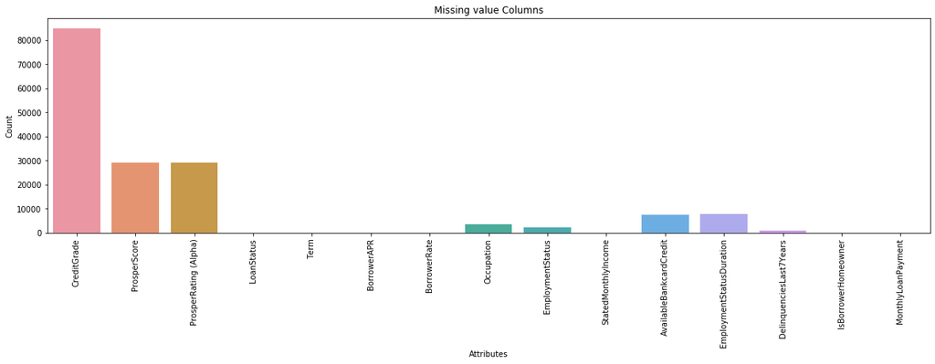

```python
# Plotting missing values as a barplot, Credit Grade, ProsperScore, ProsperRating(Alpha) are having high null percentages follwed by few other

plt.figure(figsize = (20,5))
sns.barplot(loan.isna().sum().index.values,loan.isna().sum());
plt.xlabel('Attributes')
plt.ylabel('Count')
plt.title('Missing value Columns')
plt.xticks(rotation = 90);
```

```python
# Defining a function called clean for displaying missing values in percentages

def clean(loan):
    return round(100*(loan.isnull().sum()/len(loan.index)),2).sort_values(ascending = False)
```

```python
# Displaying null percentages

nulls = clean(loan)
nulls
```

```
CreditGrade                 74.59
ProsperRating (Alpha)       25.53
ProsperScore                25.53
EmploymentStatusDuration     6.69
AvailableBankcardCredit      6.62
Occupation                   3.15
EmploymentStatus             1.98
DelinquenciesLast7Years      0.87
BorrowerAPR                  0.02
MonthlyLoanPayment           0.00
IsBorrowerHomeowner          0.00
StatedMonthlyIncome          0.00
BorrowerRate                 0.00
Term                         0.00
LoanStatus                   0.00
dtype: float64
```

```python
# Displaying columns having more than 50% of missing values, Only credit Grade column has above 50 i.e close to 75% of missing values

to_remove = nulls[nulls >= 50]
to_remove
```

```
CreditGrade    74.59
dtype: float64
```

```python
# Dropping CreditGrade column as it consists of high null percentage, imputing is not a best idea for this columns has almost 75% values are missing

loan.drop(to_remove.index, inplace = True, axis = 1)
```

```python
# Left with 113937 rows and 14 columns

print(loan.shape)
loan.head(1)
```

```
(113937, 14)
```

|  | ProsperScore | ProsperRating (Alpha) | LoanStatus | Term | BorrowerAPR | BorrowerRate | Occupation | EmploymentStatus | StatedMonthlyIncome | AvailableBankcardCredit | EmploymentStatusDuration | DelinquenciesLast7Years | IsBorrowerHomeowner | MonthlyLoanPayment |
| --- | --- | --- | --- | --- | --- | --- | --- | --- | --- | --- | --- | --- | --- | --- |
| 0 | NaN | NaN | Completed | 36 | 0.16516 | 0.158 | Other | Self-employed | 3083.333333 | 1500.0 | 2.0 | 4.0 | True | 330.43 |

```python
# Missing value percentages suggest some kind of relationship between missing values for ProsperRating (Alpha) and ProsperScore
# Looks like one column value is based on another and thus equal number of rows seem to be missing

missing = clean(loan)
missing
```

```
ProsperRating (Alpha)       25.53
ProsperScore                25.53
EmploymentStatusDuration     6.69
AvailableBankcardCredit      6.62
Occupation                   3.15
EmploymentStatus             1.98
DelinquenciesLast7Years      0.87
BorrowerAPR                  0.02
MonthlyLoanPayment           0.00
IsBorrowerHomeowner          0.00
StatedMonthlyIncome          0.00
BorrowerRate                 0.00
Term                         0.00
LoanStatus                   0.00
dtype: float64
```

```python
# Dropping rows having null values for ProsperScore as it's an important column for my analysis,shouldn't be biased because of imputation

loan = loan[~loan['ProsperScore'].isnull()]
loan.shape
```

```
(84853, 14)
```

```python
# As noticed in describe, 11 is max score for ProsperScore which is incorrect
# Retaining only rows having valid prosperscore from 1 to 10

print(loan['ProsperScore'].max())
loan = loan[loan['ProsperScore'] <= 10]
```

```
11.0
```

```python
# 'EmploymentStatusDuration' column consists of integar values, so imputing null values with median of that column

print(loan['EmploymentStatusDuration'].value_counts().head())
loan['EmploymentStatusDuration'].fillna(loan['EmploymentStatusDuration'].median(),inplace = True)
```

```
0.0    1079
4.0     813
3.0     788
5.0     781
6.0     779
Name: EmploymentStatusDuration, dtype: int64
```

```python
# 'AvailableBankcardCredit' column consists of integar values, so imputing null values with median of that column

print(loan['AvailableBankcardCredit'].value_counts().head(5))
loan['AvailableBankcardCredit'].fillna(loan['AvailableBankcardCredit'].median(),inplace = True)
```

```
0.0       2427
500.0      223
300.0      101
1000.0      98
2000.0      91
Name: AvailableBankcardCredit, dtype: int64
```

```python
# 'Occupation' column mode is given by 'Other', so imputing null values with it

print(loan['Occupation'].value_counts().head(5))
print(loan['Occupation'].mode())
loan['Occupation'] = loan['Occupation'].fillna('Other')
```

```
Other                  21031
Professional           10318
Executive               3338
Computer Programmer     3123
Teacher                 2845
Name: Occupation, dtype: int64
0    Other
dtype: object
```

```python
# 'EmploymentStatus' column mode is given by 'Employed', so imputing null values with it

print(loan['EmploymentStatus'].mode())
loan['EmploymentStatus'] = loan['EmploymentStatus'].fillna('Employed')
```

```
0    Employed
dtype: object
```

```python
# 'DelinquenciesLast7Years' column consists of integar values, so imputing null values with median of that column

loan['DelinquenciesLast7Years'].value_counts()
print(loan['DelinquenciesLast7Years'].median())
loan['DelinquenciesLast7Years'] = loan['DelinquenciesLast7Years'].fillna(loan['DelinquenciesLast7Years'].median())
```

```
0.0
```

```python
# Imputing 'BorrowerAPR' null values with it's mean value

print(loan['BorrowerAPR'].mean())
loan['BorrowerAPR'].fillna(loan['BorrowerAPR'].mean(),inplace = True)
```

```
0.22866285789652427
```

```python
# Now the dataset is clean with no missing values

m = clean(loan)
m
```

```
MonthlyLoanPayment          0.0
IsBorrowerHomeowner         0.0
DelinquenciesLast7Years     0.0
EmploymentStatusDuration    0.0
AvailableBankcardCredit     0.0
StatedMonthlyIncome         0.0
EmploymentStatus            0.0
Occupation                  0.0
BorrowerRate                0.0
BorrowerAPR                 0.0
Term                        0.0
LoanStatus                  0.0
ProsperRating (Alpha)       0.0
ProsperScore                0.0
dtype: float64
```

### 1. Who comprise of larger set of bank's customers in terms of occupation?

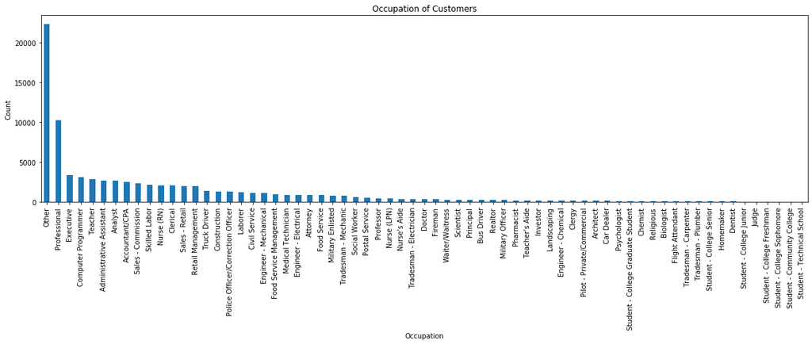

```python
# Most of the loan applicants have Occupation mentioned as 'Other',
# This includes the customers who had not specified what's their occupation and also those who didn't wish to specify the occupation

plt.figure(figsize=(20,5))
plt.xlabel('Occupation')
plt.ylabel('Count')
plt.title('Occupation of Customers')
loan['Occupation'].value_counts().plot.bar();
```

### 2. What is the distribution of AvailableBankcardCredit attribute?

```
(0, 120000)
```

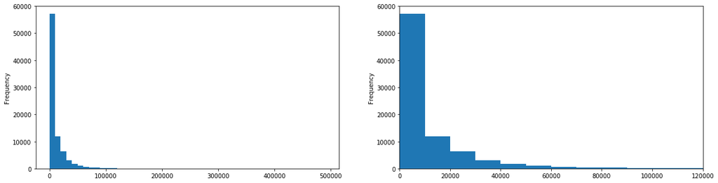

```python
# AvailableBankcardCredit maximum value is close to 500000 and most have the available credit around 10000 dollars.

b = np.arange(0,loan['AvailableBankcardCredit'].max()+1,10000)
plt.figure(figsize = (20,5))
plt.subplot(121)
loan['AvailableBankcardCredit'].plot.hist(bins = b);
plt.subplot(122)
loan['AvailableBankcardCredit'].plot.hist(bins = b);
plt.xlim(0,120000)
```

### 3. What is the distribution of ProsperScore attribute?

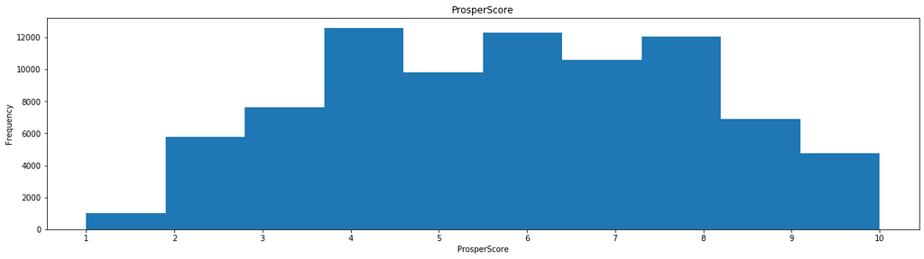

```python
# Low number of customers are given 1 as the prosper score, most of them are given score between 4 and 8

plt.figure(figsize = (20,5))
plt.xlabel('ProsperScore')
plt.title('ProsperScore')
loan['ProsperScore'].plot.hist(color=sns.color_palette()[0]);
plt.xticks(np.arange(1,loan['ProsperScore'].max()+1,1));
```

### 4. What is the distribution of DelinquenciesLast7Years attribute?

```
0.0
```

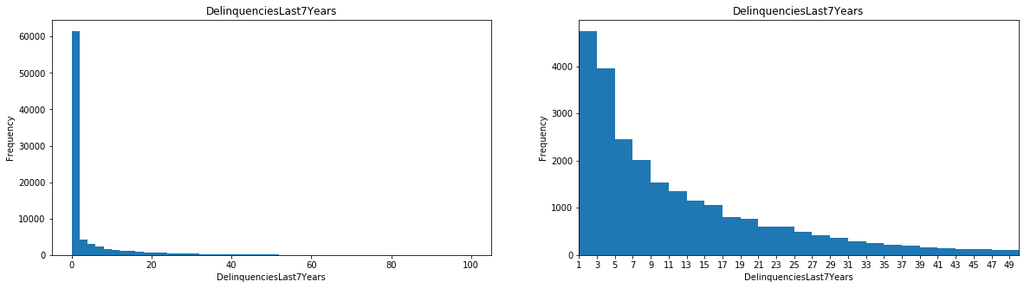

```python
# It can be seen that maximum number of customers have not missed their installment, maximum of number of misses is close to 100

bins = np.arange(0,loan['DelinquenciesLast7Years'].max()+2,2)
plt.figure(figsize = (20,5))
plt.subplot(121)
plt.xlabel('DelinquenciesLast7Years')
plt.title('DelinquenciesLast7Years')
loan['DelinquenciesLast7Years'].plot.hist(color=sns.color_palette()[0], bins = bins);

# Next maximum number of misses is 1, number of deliquencies is gradually reducing, which is a good sign as most customers tend to not default the loan
plt.subplot(122)
bins = np.arange(1,loan['DelinquenciesLast7Years'].max()+2,2)
plt.xlabel('DelinquenciesLast7Years')
plt.title('DelinquenciesLast7Years')
loan['DelinquenciesLast7Years'].plot.hist(color=sns.color_palette()[0], bins = bins);
plt.xticks(np.arange(1,loan['DelinquenciesLast7Years'].max()+2,2))
plt.xlim(1,50)

loan['DelinquenciesLast7Years'].min()
```

### 5. What is the distribution of EmploymentStatusDuration attribute?

```
(0, 100)
```

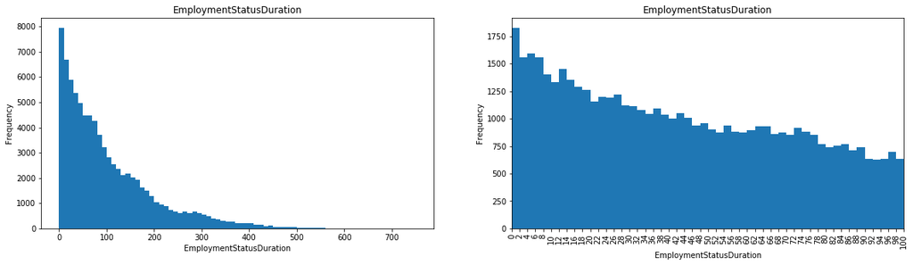

```python
# Customers who are new to their job seem to apply for loan more frequently than others

plt.figure(figsize = (20,5))
plt.subplot(121)
b = np.arange(0,loan['EmploymentStatusDuration'].max()+1,10)
plt.xlabel('EmploymentStatusDuration')
plt.title('EmploymentStatusDuration')
loan['EmploymentStatusDuration'].plot.hist(bins = b);

plt.subplot(122)
bins = np.arange(0,loan['EmploymentStatusDuration'].max()+2,2)
plt.xlabel('EmploymentStatusDuration')
plt.title('EmploymentStatusDuration')
loan['EmploymentStatusDuration'].plot.hist(color=sns.color_palette()[0], bins = bins);
plt.xticks(np.arange(0,loan['EmploymentStatusDuration'].max()+2,2))
plt.xticks(rotation = 90)
plt.xlim(0,100)
```

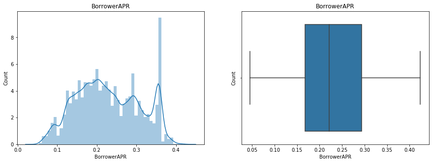

```python
# Most customers have borrowed loan at the annual percentage rate of 0.37, mean comes around 0.22

plt.figure(figsize=(15,5))

plt.subplot(121)
plt.ylabel('Count')
plt.title('BorrowerAPR')
sns.distplot(loan['BorrowerAPR']);
plt.subplot(122)
plt.ylabel('Count')
plt.title('BorrowerAPR')
sns.boxplot(loan['BorrowerAPR']);
```

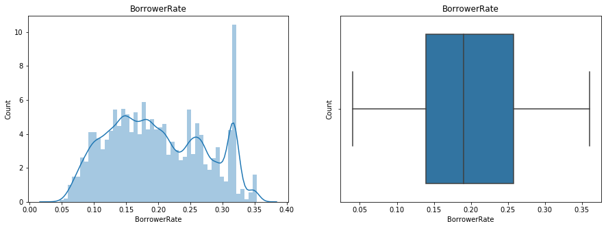

```python
# Most customers have borrowed loan at the rate of 0.33, mean comes around 0.19

plt.figure(figsize=(15,5))
plt.subplot(121)
plt.ylabel('Count')
plt.title('BorrowerRate')
sns.distplot(loan['BorrowerRate']);
loan['BorrowerRate'].value_counts(normalize =  True)
plt.subplot(122)
plt.ylabel('Count')
plt.title('BorrowerRate')
sns.boxplot(loan['BorrowerRate']);
```

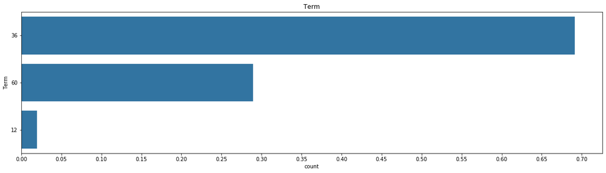

```python
# Close to 68% of customers have opted 36 month intsallment scheme, next favorite is 60 months with 29% of customers opting for it

perc = loan['Term'].value_counts( normalize = True)
ordered = perc.index
ticks_p = np.arange(0.00,perc.max()+0.01,0.05)
ticks_l = ['{:0.2f}'.format(val) for val in ticks_p]
plt.figure(figsize = (20,5))
plt.title('Term')
sns.countplot(data = loan, y = 'Term',color=sns.color_palette()[0], order = ordered);
plt.xticks(ticks_p*loan.shape[0],ticks_l);
```

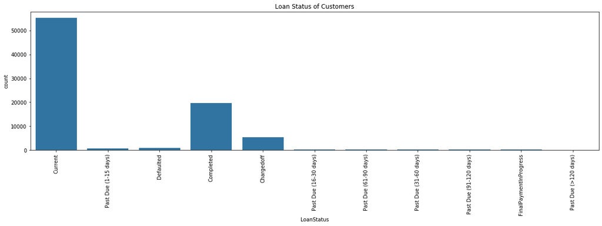

```python
# Most of the loan applicants have ongoing loans, assuring good cash flow for the bank if not defaulted

plt.figure(figsize = (20,5))
plt.title('Loan Status of Customers')
sns.countplot(loan['LoanStatus'],color=sns.color_palette()[0]);
plt.xticks(rotation = 90);
```

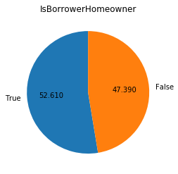

```python
# Customers having own property seem to be applying for loan more than not being a owner customers though there is no much of a difference between their proportion

s = loan['IsBorrowerHomeowner'].value_counts()
plt.title('IsBorrowerHomeowner')
plt.pie(s, labels = s.index, autopct = '%1.3f', startangle = 90);
```

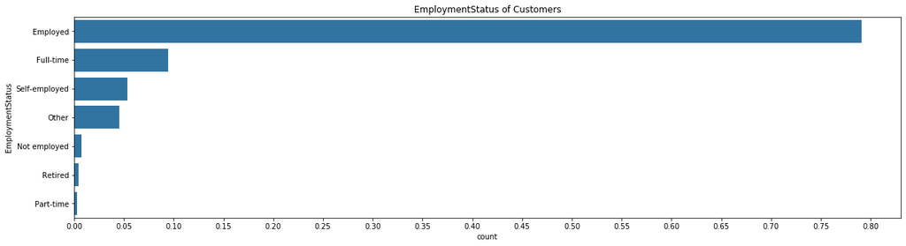

```python
# Around 79 % of customers are employed, also there are columns such as Full-time, part-time which are seperated from Employed
# May be Employed column could have been ommitted during data gathering process and right information should have been filled up in other columns

plt.figure(figsize = (20,10))

perc = loan['EmploymentStatus'].value_counts(normalize = True)
ordered = perc.index
ticks_p = np.arange(0.00,perc.max()+0.01,0.05)
ticks_l = ['{:0.2f}'.format(val) for val in ticks_p]
plt.figure(figsize = (20,5))
plt.title('EmploymentStatus of Customers')
sns.countplot(data = loan, y = 'EmploymentStatus',color=sns.color_palette()[0], order = ordered);
plt.xticks(ticks_p*loan.shape[0],ticks_l);
```

### Observations of Univariate Analysis:

1. Most of the loan applicants have Occupation mentioned as 'Other', This includes the customers who had not specified what's their occupation and also those who didn't wish to specify the occupation
2. AvailableBankcardCredit maximum value is close to 500000 and most have the available credit around 10000 dollars.
3. Around 79 % of customers are employed, also there are columns such as Full-time, part-time which are separated from Employed. May be Employed column could have been omitted during data gathering process and right information should have been filled up in other columns.
4. Low number of customers are given 1 as the prosper score, most of them are given score between 4 and 8.
5. It can be seen that maximum number of customers have not missed their instalment, maximum of number of misses is close to 100.
6. Next maximum number of misses is 1, number of delinquencies is gradually reducing, which is a good sign as most customers tend to not default the loan.
7. Customers who are new to their job seem to apply for loan more frequently than others.
8. Most customers have borrowed loan at the annual percentage rate of 0.37, mean comes around 0.22
9. Most customers have borrowed loan at the rate of 0.33, mean comes around 0.19.
10. Close to 68% of customers have opted 36 month instalment scheme, next favourite is 60 months with 29% of customers opting for it
11. Most of the loan applicants have ongoing loans, assuring good cash flow for the bank if not defaulted.
12. Customers having own property seem to be applying for loan more than not being a owner customers though there is no much of a difference between their proportion.

### Bivariate Analysis

```python
loan.head()
```

|  | ProsperScore | ProsperRating (Alpha) | LoanStatus | Term | BorrowerAPR | BorrowerRate | Occupation | EmploymentStatus | StatedMonthlyIncome | AvailableBankcardCredit | EmploymentStatusDuration | DelinquenciesLast7Years | IsBorrowerHomeowner | MonthlyLoanPayment |
| --- | --- | --- | --- | --- | --- | --- | --- | --- | --- | --- | --- | --- | --- | --- |
| 1 | 7.0 | A | Current | 36 | 0.12016 | 0.0920 | Professional | Employed | 6125.000000 | 10266.0 | 44.0 | 0.0 | False | 318.93 |
| 3 | 9.0 | A | Current | 36 | 0.12528 | 0.0974 | Skilled Labor | Employed | 2875.000000 | 30754.0 | 113.0 | 14.0 | True | 321.45 |
| 4 | 4.0 | D | Current | 36 | 0.24614 | 0.2085 | Executive | Employed | 9583.333333 | 695.0 | 44.0 | 0.0 | True | 563.97 |
| 5 | 10.0 | B | Current | 60 | 0.15425 | 0.1314 | Professional | Employed | 8333.333333 | 86509.0 | 82.0 | 0.0 | True | 342.37 |
| 6 | 2.0 | E | Current | 36 | 0.31032 | 0.2712 | Sales - Retail | Employed | 2083.333333 | 1929.0 | 172.0 | 0.0 | False | 122.67 |

### 1. What is the relationship between numeric variables?

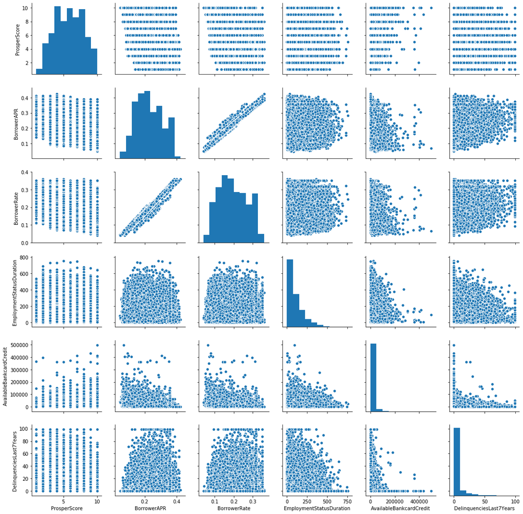

```python
sns.pairplot(loan, vars = ['ProsperScore','BorrowerAPR','BorrowerRate','EmploymentStatusDuration',
                           'AvailableBankcardCredit','DelinquenciesLast7Years']);
```

```
(8.0, -0.5)
```

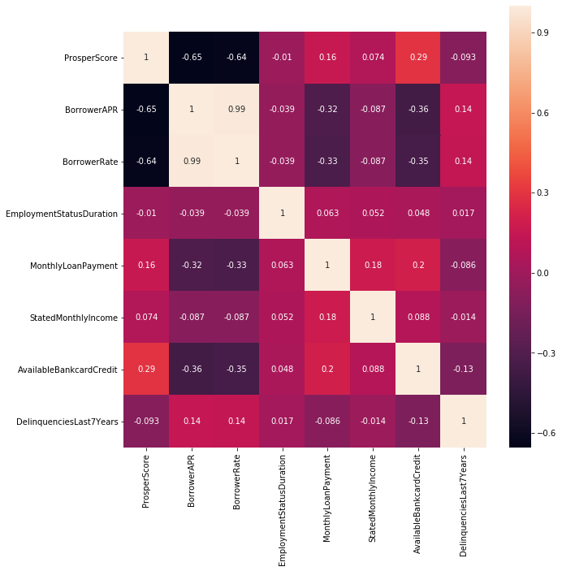

```python
# Prosper score and Borrower APR, Borrower Rate are negatively correlated. Lower the APR, higher the prosper Score

plt.figure(figsize = [10,10])
var = ['ProsperScore','BorrowerAPR','BorrowerRate','EmploymentStatusDuration','MonthlyLoanPayment',
                           'StatedMonthlyIncome','AvailableBankcardCredit','DelinquenciesLast7Years']
ax = sns.heatmap(loan[var].corr(), annot = True);
bottom, top = ax.get_ylim()
ax.set_ylim(bottom + 0.5, top = -0.5)
```